# Sleep Disorder KNN Predictor

Daniela Frade Noguez

2025-09-25

## Introduction

This report explores the **Sleep Health and Lifestyle Dataset** and builds a KNN model to classify sleep disorders using different lifestyle and health-related predictors. In this analysis, the target variable will be Sleep_Disorder, which classifies each individual as None, Sleep Apnea, or Insomnia.

### Predictors used:

- Age
- Sleep Duration
- Quality of Sleep
- Physical Activity Level
- Stress Level
- Daily Steps
- Systolic (blood pressure)
- Diastolic (blood pressure)
- BMI_num (numeric encoding of BMI category)
- Gender_num (numeric encoding of gender)

### Methods and Plan

- Clean data set
- Visualize class distributions
- Tune KNN model
- Train KNN model
- Evaluate performance with accuracy, precision, recall, and confusion matrix
- Interpret results
- Next steps

### Load Packages and set seed for reproducibility

```r
set.seed(123)
library(tidyverse)
library(tidymodels)
library(themis)
```

### Read data set

```r
sleep_data <- read_csv("data/Sleep_health_and_lifestyle_dataset.csv")
head(sleep_data)
```

```
## # A tibble: 6 × 13
##   `Person ID` Gender   Age Occupation        `Sleep Duration` `Quality of Sleep`
##         <dbl> <chr>  <dbl> <chr>                        <dbl>              <dbl>
## 1           1 Male      27 Software Engineer              6.1                  6
## 2           2 Male      28 Doctor                         6.2                  6
## 3           3 Male      28 Doctor                         6.2                  6
## 4           4 Male      28 Sales Representa…              5.9                  4
## 5           5 Male      28 Sales Representa…              5.9                  4
## 6           6 Male      28 Software Engineer              5.9                  4
## # ℹ 7 more variables: `Physical Activity Level` <dbl>, `Stress Level` <dbl>,
## #   `BMI Category` <chr>, `Blood Pressure` <chr>, `Heart Rate` <dbl>,
## #   `Daily Steps` <dbl>, `Sleep Disorder` <chr>
```

### Clean data set

First we clean the data set by renaming columns, assigning numerical values to categorical variables to use them as predictors.

```r
sleep_data_clean <- sleep_data |>
  select(-`Person ID`, -`Heart Rate`, -`Occupation`)|>
  rename(Sleep_Disorder = `Sleep Disorder`)|>
  rename(Gender = `Gender`)|>
  rename(Age = `Age`)|>
  rename(Sleep_Duration = `Sleep Duration`)|>
  rename(Quality_of_Sleep = `Quality of Sleep`)|>
  rename(Physical_Activity_Level = `Physical Activity Level`)|>
  rename(Stress_Level = `Stress Level`)|>
  rename(BMI_Category = `BMI Category`)|>
  rename(Blood_Pressure = `Blood Pressure`)|>
  rename(Daily_Steps = `Daily Steps`)|>
  separate(Blood_Pressure, into = c("Systolic", "Diastolic"), sep = "/") |>
  mutate(Systolic = as.numeric(Systolic), Diastolic = as.numeric(Diastolic)) |>
  mutate(BMI_num = case_when(BMI_Category == "Underweight" ~ 1,
                             BMI_Category == "Normal"~ 2,
                             BMI_Category == "Overweight"  ~ 3,
                             BMI_Category == "Obese" ~ 4))|>

  mutate(Gender_num = case_when(Gender == "Male" ~ 1,
                                Gender == "Female"~ 2))|>
  select(-BMI_Category, -Gender) |>

  mutate(Sleep_Disorder = as_factor(Sleep_Disorder)) |>
  drop_na()
head(sleep_data_clean)
```

```
## # A tibble: 6 × 11
##     Age Sleep_Duration Quality_of_Sleep Physical_Activity_Level Stress_Level
##   <dbl>          <dbl>            <dbl>                   <dbl>        <dbl>
## 1    27            6.1                6                      42            6
## 2    28            6.2                6                      60            8
## 3    28            6.2                6                      60            8
## 4    28            5.9                4                      30            8
## 5    28            5.9                4                      30            8
## 6    28            5.9                4                      30            8
## # ℹ 6 more variables: Systolic <dbl>, Diastolic <dbl>, Daily_Steps <dbl>,
## #   Sleep_Disorder <fct>, BMI_num <dbl>, Gender_num <dbl>
```

### Visualize class distributions

It is important to visualize the distribution of the target variable (Sleep_Disorder) distribution in our data set. If one category of the class has more observations than the other, the KNN model becomes biased towards that category, meaning it is more likely to predict that category. This occurs because KNN makes predictions based on the “closest” observations using euclidean distance, and the majority class will naturally have more neighbors available. From this graph we can see that there are more “none” observations in our data set, thus we will have to balance them before making any predictions to avoid bias.

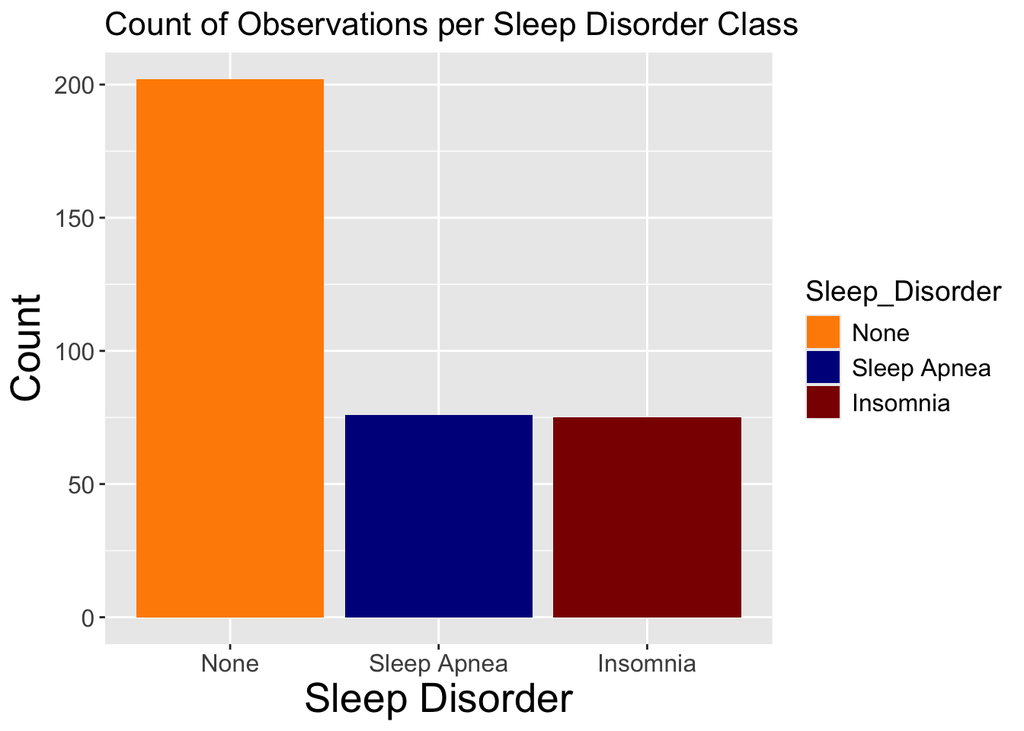

```r
counts_graph <- ggplot(sleep_data_clean, aes(x = Sleep_Disorder, fill = Sleep_Disorder)) +
  geom_bar() +
  xlab("Sleep Disorder") +
  ylab("Count") +
  ggtitle("Count of Observations per Sleep Disorder Class")+
  theme(
    axis.title = element_text(size = 20),
    axis.text = element_text(size = 12),
    plot.title = element_text(size = 16),
    legend.title = element_text(size = 14),
    legend.text = element_text(size = 12)) +
  scale_fill_manual(values = c("darkorange", "darkblue", "darkred"))
counts_graph
```

### Tune KNN model

To make the model as accurate as possible, we need to decide how much observations (neighbors or k) it should use when classifying a new observation. We experiment with different settings of k in a range of 1 to the size of the testing set and compare how well the model performs with each.

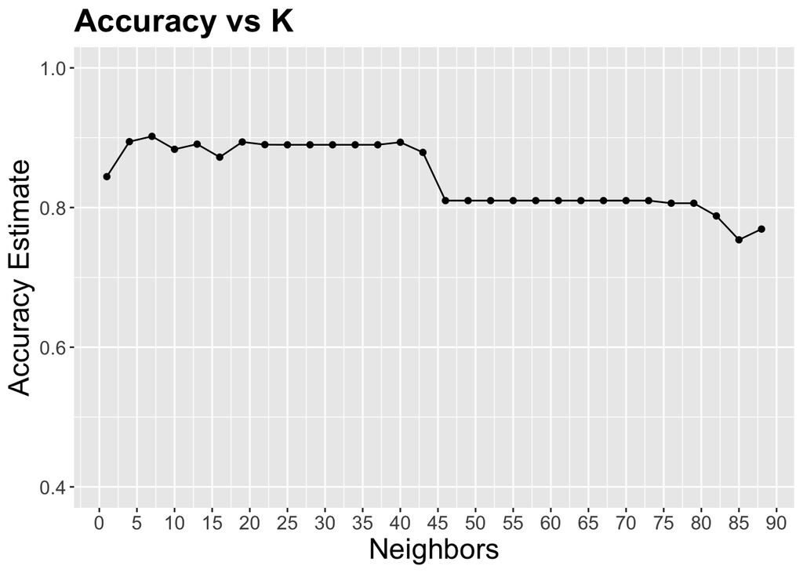

```r
sleep_split <- initial_split(sleep_data_clean, prop = 0.75, strata = Sleep_Disorder)
sleep_training <- training(sleep_split)
sleep_testing <- testing(sleep_split)

knn_tune <- nearest_neighbor(weight_func = "rectangular", neighbors = tune()) |>
  set_engine("kknn") |>
  set_mode("classification")

k_vals <- tibble(neighbors = seq(from = 1, to = 89, by = 3))

num_vfold <- vfold_cv(sleep_training, v = 5, strata = Sleep_Disorder)

sleep_recipe <- recipe(Sleep_Disorder ~ ., data = sleep_training) |>
  step_upsample(Sleep_Disorder, over_ratio = 1, skip = TRUE) |>
  step_scale(all_predictors()) |>
  step_center(all_predictors())

knn_results <- workflow() |>
  add_recipe(sleep_recipe) |>
  add_model(knn_tune) |>
  tune_grid(resamples = num_vfold, grid = k_vals) |>
  collect_metrics()


accuracies <- knn_results |>
  filter(.metric == "accuracy")

k_plot <- accuracies |>
  ggplot(aes(x = neighbors, y = mean)) +
  geom_point() +
  geom_line() +
  labs(
    title = "Accuracy vs K",
    x = "Neighbors",
    y = "Accuracy Estimate"
  ) +
  scale_x_continuous(breaks = seq(0, 90, by = 5)) +
  scale_y_continuous(limits = c(0.4, 1.0)) +
  theme(
    axis.title.x = element_text(size = 18),
    axis.title.y = element_text(size = 18),
    axis.text = element_text(size = 12),
    plot.title = element_text(size = 20, face = "bold")
  )

best_k <- accuracies |>
  arrange(desc(mean)) |>
  head(1) |>
  pull(neighbors)
k_plot
```

```r
best_k
```

```
## [1] 7
```

From the plot, we can see that the number of neighbors that gives us the highest accuracy is 7.

```r
knn_model_with_best_k <- nearest_neighbor(weight_func = "rectangular", neighbors = best_k) |>
  set_engine("kknn") |>
  set_mode("classification")

knn_fit <- workflow() |>
  add_recipe(sleep_recipe) |>
  add_model(knn_model_with_best_k) |>
  fit(data = sleep_training)
```

### Evaluate performance with accuracy, precision, recall, and confusion matrix

```r
sleep_test_pred <- predict(knn_fit, sleep_testing) |>
  bind_cols(sleep_testing)

sleep_accuracy <- sleep_test_pred |>
  metrics(truth = Sleep_Disorder, estimate = .pred_class) |>
  filter(.metric == "accuracy")

sleep_prediction <- sleep_test_pred|>
  precision(truth = Sleep_Disorder, estimate = .pred_class, event_level="first")

sleep_recall <- sleep_test_pred|>
  recall(truth = Sleep_Disorder, estimate = .pred_class, event_level="first")

confusion_matrix <- sleep_test_pred |>
  conf_mat(truth = Sleep_Disorder, estimate = .pred_class)


sleep_accuracy
```

```
## # A tibble: 1 × 3
##   .metric  .estimator .estimate
##   <chr>    <chr>          <dbl>
## 1 accuracy multiclass     0.843
```

```r
sleep_prediction
```

```
## # A tibble: 1 × 3
##   .metric   .estimator .estimate
##   <chr>     <chr>          <dbl>
## 1 precision macro          0.810
```

```r
sleep_recall
```

```
## # A tibble: 1 × 3
##   .metric .estimator .estimate
##   <chr>   <chr>          <dbl>
## 1 recall  macro          0.831
```

```r
confusion_matrix
```

```
##              Truth
## Prediction    None Sleep Apnea Insomnia
##   None          44           2        2
##   Sleep Apnea    3          16        2
##   Insomnia       4           1       15
```

```r
acc_val   <- sleep_accuracy$.estimate
prec_val  <- sleep_prediction$.estimate
recall_val <- sleep_recall$.estimate
```

### Interpretation of results

#### Results:

- Accuracy: 0.8426966
- Precision: 0.8095238
- Recall: 0.8314413
- Confusion matrix:

```
##              Truth
## Prediction    None Sleep Apnea Insomnia
##   None          44           2        2
##   Sleep Apnea    3          16        2
##   Insomnia       4           1       15
```

#### Interpretation:

- **Accuracy:** The model predicted the correct sleep disorder (None, Sleep Apnea, or Insomnia) 84.2696629% of the time.
- **Precision:** On average across all classes, when the model predicted a person’s sleep disorder, it was correct 80.952381% of the time.
- **Recall:** On average across all classes, the model correctly identified 83.1441348% of individuals with their true sleep disorder.

### Next Steps

Overall, the model is effective however it may benefit by tuning it to optimize recall. This way, we minimize the amounts of false negatives and we avoid diagnosing someone with no sleep disorder when they may be at risk of one.

### References

Kaggle. (2025). Lifestyle and Sleep Patterns [Data set]. Kaggle. https://www.kaggle.com/datasets/minahilfatima12328/lifestyle-and-sleep-patterns

Timbers, T., Campbell, T., & Lee, M. (2024). Data science: A first introduction.